# Predictive Checks – Iteration in Regression

This week you will learn:

- how to make predictions from a linear model
- how to include variability into predictions
- what is assumed about the data generating process in a linear regression
- how to assess if the assumed linear model accurately describes the observed data

**This week everything is self-contained in this coursework page!**

📖 Readings: 15-30 minutes

💻 Activities: 10-15 minutes

✅ Check-ins: 5 (combined in 1 Canvas quiz)

> It is difficult to include in a [statistical model] all of one’s knowledge about a problem, and so it is wise to investigate what aspects of reality are not captured by the model.  
> - Andrew Gelman, *Bayesian Data Analysis*

# 1 Model Checking

In explanatory modeling, it is incredibly important to check if you can make sound inferences from the model that was fit. Whether the model is a “simple” difference in means or a more “complex” multiple linear regression, the estimated coefficients obtained from the model should not be used for inference if the conditions of the model are violated. Typically, model checking for a linear regression is taught through a “residual analysis,” inspecting different visualizations of the residuals from the model. This week, however, we will learn a different way to assess our regression model.

## 1.1 Predictive Checks, Bayesian Modeling, and Subjectivity

The idea of *predictive checks* for a statistical model are most often seen in the context of Bayesian modeling. In Bayesian modeling, rather than obtaining a single estimate for a parameter, you obtain a distribution of plausible values for that parameter. The distribution suggests which values of that parameter are more or less likely, given what was seen in the data and the prior knowledge incorporated into the model.

[figure not shown]

The prior knowledge about what values we expect for the parameter comes in the form of a *prior distribution*. Different statisticians may choose a different prior distributions, much like different statisticians might choose different variables to include in their regression. Although there are large similarities between the choice of a prior distribution and the choice of a statistical model, prior distributions receive a great deal of flack for how the interlace “subjectivity” into the statistical modeling process.

Due in part to these criticisms regarding the choice of a prior distribution, it is common in Bayesian analyses to perform predictive checks to assess the fit of the model to the data at hand. While we are not fitting Bayesian models, I believe there is a great deal we can learn from the concept of using predictive checks for **any** statistical model. Any good analysis should include a check of the “adequacy of the fit of the model to the data and the plausibility of the model for the purposes for which the model will be used” (Gelman et al., 2020, p. 141).

## 1.2 Predictive Checks in a Linear Regression

Under a linear simple regression model, we assume that the responses can be modeled as a linear function of the explanatory variable and some error:

$$\text{y} = \beta_0 + \beta_1 \times x_1 + \epsilon$$

In a linear model we assume that the errors ($\epsilon$) follow a Normal distribution with mean 0 and standard deviation $\sigma$ ($\epsilon \sim N(0, \sigma)$).

This implies that we can simulate data that we would expect to come from this model, by adding normally distributed errors to the values predicted from the linear regression. Moreover, when we randomly generate these errors, we better understand what the “normality,” “equal variance,” and “independence” conditions mean in the context of the linear regression model.

### Connection to Model Conditions

A linear regression model has four conditions, which follow the LINE acronym:

**L**inear relationship between $x$ and $y$  
**I**ndependence of observations  
**N**ormality of residuals  
**E**qual variance of residuals

The first condition relates to the relationship between the explanatory ($x$) and response ($y$) variable. As you might expect, using a line to model a non-linear relationship is a bad choice! Thus, we will only make predictions from a linear regression where there appears to be a linear relationship between the variables.

The process of adding normally distributed errors to the predictions from the linear regression assumes three things:

1. the errors follow a specific distribution, namely $N(0, \sigma)$
2. the errors all have the same variance ($\sigma$)
3. the errors are not related to each other

The Normality and equal variance conditions are manifested in using the $N(0, \sigma)$ distribution to generate the errors. The independence condition is manifested in the assumption that we can draw random errors for each observation (prediction), because the errors are not related to each other.

This might feel like a bit of a stretch, especially if you haven’t seen linear regression in a bit, so let me break this down a bit more. When we assume that observations are independent, we are saying that we shouldn’t be able to know the $y$ value for one observation just from knowing the $y$ value of another observation. If I have repeated observations, like values for the same country across multiple years, then it’s pretty likely that I can guess the value of a variable in 1991 from knowing the same variable’s value in 1990. Since we are using a linear regression to model the relationship between the explanatory variable(s) and the response, this assumption can be rephrased in terms of each observation’s residual. Specifically, knowing the residual for one observation shouldn’t give us perfect information about the residual for another observation. Because we are assuming that the observations / residuals are independent, we can randomly draw an errors for each observation.

# 2 Performing a Predicitive Check for a Linear Regression

I will be walking through how to carry out the process of performing a predictive check for a simple linear regression model in the context of the `penguins` dataset from the **palmerpenguins** package.

We will start by fitting a simple linear regression model, modeling a penguin’s `body_mass_g` as a function of their `flipper_length_mm`.

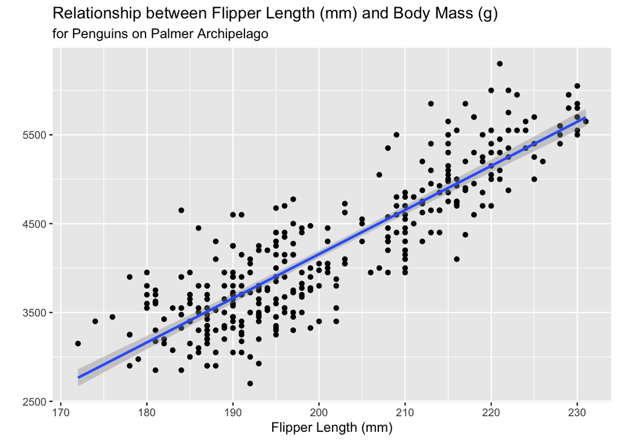

```r
penguins |>
  ggplot(mapping = aes(x = flipper_length_mm, y = body_mass_g)) +
  geom_point() +
  geom_smooth(method = "lm") +
  labs(x = "Flipper Length (mm)",
       y = "",
       title = "Relationship between Flipper Length (mm) and Body Mass (g)",
       subtitle = "for Penguins on Palmer Archipelago")
```

```r
penguin_lm <- penguins |>
  lm(body_mass_g ~ flipper_length_mm, data  = _)
```

## 2.1 Obtaining Predictions

The next step is to obtain the predictions (fitted values) from the regression model. There is a handy built-in function for extracting the predicted values from a `lm` object – the `predict()` function.

```r
penguin_predict <- predict(penguin_lm)
```

✅ **Check-in: The `predict()` function**

What is the data structure of the predictions that are output by the `predict()` function?

1. list
2. vector
3. matrix
4. dataframe

## 2.2 Extracting the Estimate of $\sigma$

The residual standard error shown in the `summary()` output of a linear regression is the “best” estimate for the value of $\sigma$. We can extract this value using the built-in `sigma()` function and save it in an object for later use.

```r
penguin_sigma <- sigma(penguin_lm)
```

## 2.3 Adding Errors / Noise to Predictions

As stated before, under a linear regression model, we can simulate data that we would have expected to come from this model, by adding normally distributed errors to the values predicted from the linear regression.

Thus, it is useful for us to write a function that adds Normally distributed errors to a vector, `x`, given the value of `sd` input. I’ve written one such function here:

```r
noise <- function(x, mean = 0, sd){
  x + rnorm(length(x),
            mean = mean,
            sd = sd)
}
```

Next, we can use this function to generate a new dataset with observations we would have expected to come from our linear regression. Note I’m storing these predictions in a `tibble()`, so that I can easily plot them later!

```r
new_data <- tibble(predict_mass = noise(penguin_predict,
                                        sd = penguin_sigma
                                          )
                   )
```

✅ **Check-in: Normal Errors**

What does a mean of 0 imply for the residuals?

# 3 Plotting Predictions

The best way to assess if / where there are differences between the simulated data and the observed data is through visualizations. We can do this in two ways, (1) visualizing the distribution of the responses, and (2) visualizing the relationship between the responses and the explanatory variables.

## 3.1 Distribution of Responses

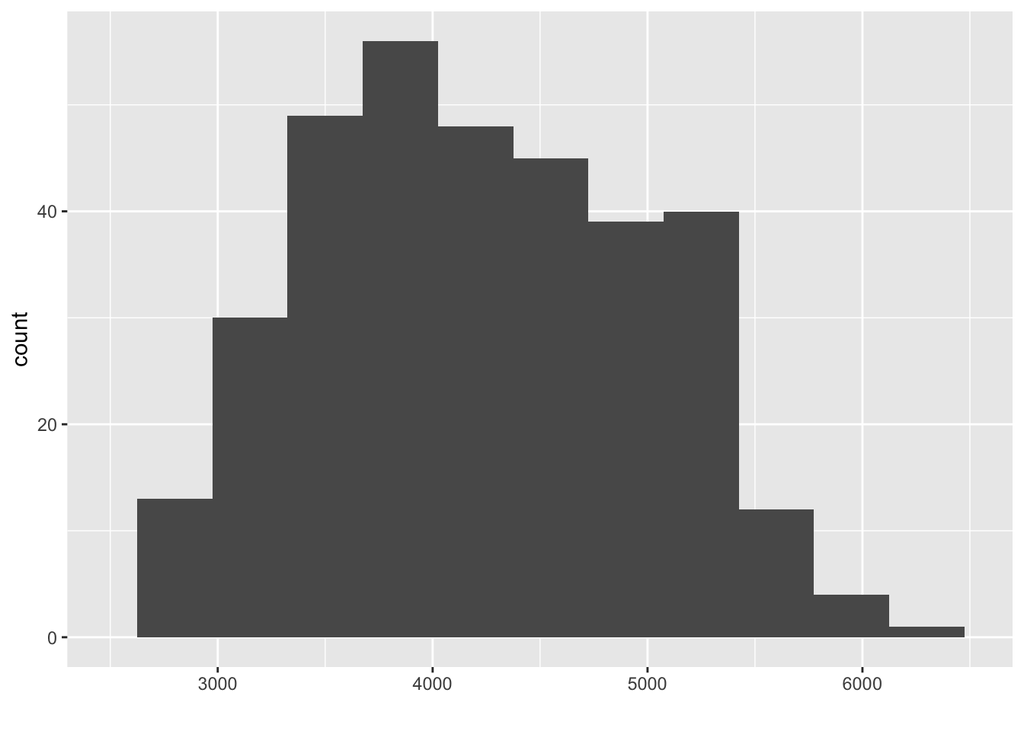

Simulated Body Mass (g)

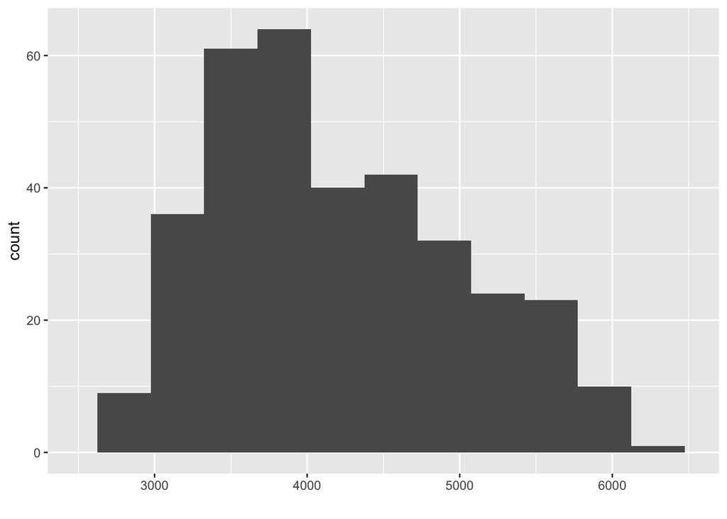

Observed Body Mass (g)

```r
new_data |>
  ggplot(aes(x = predict_mass)) +
  geom_histogram(binwidth = 350) +
  labs(x = " ") +
  xlim(2500, 6500)
penguins |>
  ggplot(aes(x = body_mass_g)) +
  geom_histogram(binwidth = 350) +
  labs(x = " ") +
  xlim(2500, 6500)
```

✅ **Check-in: Simulated Data Distribution**

## 3.2 Adding in the Observed x’s

If we are interested in seeing if the observed relationships between `flipper_length_mm` and `body_mass_g` are radically different from the simulated data, we need to add these variables into our simulated dataset.

Remember, by default `lm()` throws out any observations with missing values (`NA`) for any of the variables included in the regression. Thus, we will have fewer predictions than observations in our dataset. To make sure the predictions match up with their corresponding row, we need to filter the missing values out of the dataset before we bind the columns together.

```r
new_data <- penguins |>
  drop_na(body_mass_g,
          flipper_length_mm) |>
  select(body_mass_g, flipper_length_mm) |>
  bind_cols(new_data)
```

**`bind_cols()`**

Note that I’m using `bind_cols()` instead of a `left_join()` since the vector of predictions (stored in `new_data`) does not have a variable to join the dataset with.

## 3.3 Scatterplot of Relationships

A scatterplot of the relationships modeled by the linear regression can give a more detailed idea for where the simulated data differ from the observed data. In the scatterplots below, we see that the data simulated from the regression more closely follows a linear relationship, but there are not dramatic differences between the two scatterplots.

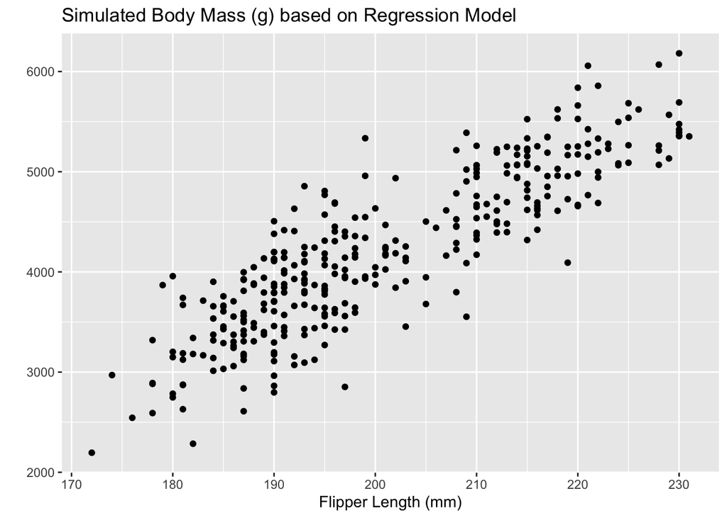

Simulated Body Masses

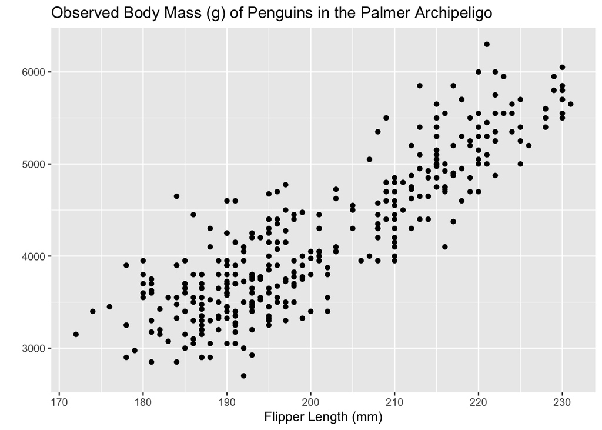

Observed Body Masses

```r
new_data |>
  ggplot(aes(y = predict_mass,
             x = flipper_length_mm)) +
  geom_point() +
  labs(x = "Flipper Length (mm)",
       y = "",
       title = "Simulated Body Mass (g) based on Regression Model")
penguins |>
  ggplot(aes(y = body_mass_g,
             x = flipper_length_mm)) +
  geom_point() +
    labs(x = "Flipper Length (mm)",
       y = "",
       title = "Observed Body Mass (g) of Penguins in the Palmer Archipeligo")
```

# 4 Assessing Predictions

We would expect that if the regression model is a good model for penguin body mass, then the simulated data should look similar to what was observed. We can compare the simulated data with the observed data using a scatterplot.

If the simulated data were identical to the observed data, they would all fall on the $y = x$ line (in red). Values above the $y = x$ line correspond to simulated body masses larger than the observed body masses, and values below the line correspond to simulated body masses smaller than the observed body masses. Overall, it appears that there are about as many over estimates as underestimates. It appears there is a “moderate” relationship between the observed values and simulated values, as the points are fairly close to the line, but not extremely close.

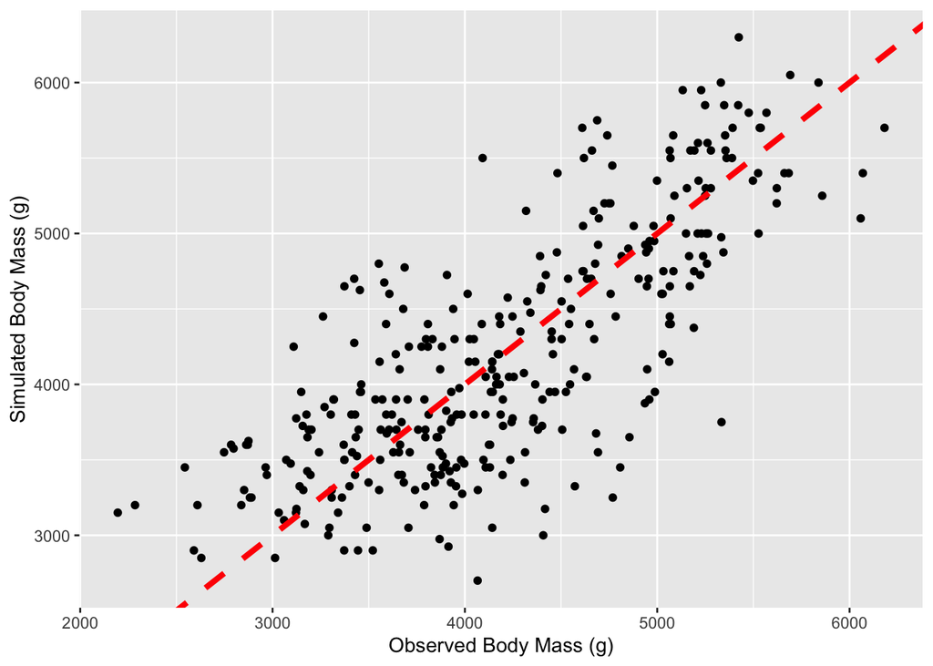

```r
new_data |>
  ggplot(aes(x = predict_mass, y = body_mass_g)) +
  geom_point() +
   labs(x = "Observed Body Mass (g)",
       y = "Simulated Body Mass (g)" ) +
  geom_abline(slope = 1,
              intercept = 0,
              color = "red",
              linetype = "dashed",
              lwd = 1.5)
```

We can use a statistic to summarize how “close” the simulated values and the observed values are. Any statistic that captures the residuals from this regression would do. I like $R^2,$ since it has an easy reference value for what I would expect if my model did a good job ($R^2 \approx 1$).

I like the `glance()` function from the **broom** package, since it produces a nice table output of the summary measures from a linear regression.

```r
new_data |>
  lm(body_mass_g ~ predict_mass, data = _) |>
  glance()
```

| r.squared | adj.r.squared | sigma | statistic | p.value | df | logLik | AIC | BIC | deviance | df.residual | nobs |
| --- | --- | --- | --- | --- | --- | --- | --- | --- | --- | --- | --- |
| 0.5868277 | 0.5856125 | 516.2417 | 482.9012 | 0 | 1 | -2620.603 | 5247.205 | 5258.71 | 90611870 | 340 | 342 |

I can then use the column names of the table to `select()` the `r.squared` column.

```r
new_data |>
  lm(body_mass_g ~ predict_mass, data = _) |>
  glance() |>
  select(r.squared) |>
  pull()
```

```
[1] 0.5868277
```

✅ **Check-in: Interpreting** $R^2$

What does the $R^2$ value for the above regression mean? How would you interpret it?

# 5 Iterating!

We are interested in seeing how our model performs for more than one simulated dataset. Thus, we need to iterate through the process outlined above. Specifically, at each step we will need to:

1. Simulate new data
2. Regress the new data on the observed data
3. Save the $R^2$ from the regression

## 5.1 Lots of Simulated Observations

Luckily, we have already written the `noise()` function that helps us simulate new observations that could have occurred under our model. Since we are not changing any input to `noise()`, we can choose between passing an “arbitrary” input to `map()` (e.g., `1:100`). This essentially rerun the same process multiple times. Since we want for every simulated dataset to be bound together as columns, we can use the `map__dfc()` function!

```r
nsims <- 100

sims <- map_dfc(.x = 1:nsims,
                .f = ~ tibble(sim = noise(penguin_predict, sd = penguin_sigma)
                              )
                )
```

Since all of the columns have the same name, **dplyr** automatically adds `...` and a number after each column. So, our column names look like `sim...1`, `sim...2`, etc. It would be nice to replace the `...`s with a `_`, which our friend `str_replace_all()` can help us do! Remember, the `.` is a special character and needs to be escaped!

```r
colnames(sims) <- colnames(sims) |>
  str_replace(pattern = "\\.\\.\\.",
                  replace = "_")
```

Finally, we can add the observed into our simulated dataset, for ease of modeling and visualizing.

```r
sims <- penguins |>
  drop_na(body_mass_g,
         flipper_length_mm) |>
  select(body_mass_g) |>
  bind_cols(sims)
```

## 5.2 Lots of Regressions & $R^2$ Values

Now, we want to regress each of these simulated `body_mass_g`s on the original, observed `body_mass_g`. Again, we will need to iterate through this process.

Before, I fit a linear regression between `body_mass_g` and the simulated data. Now, I have 100 different datasets I need to regress on `body_mass_g`. I can use `map()` to define a function that will be applied to each column of `sims`. This function regresses `body_mass_g` on each column (`.x`) from the `sims` dataset.

```r
sims |>
  map(.f = ~lm(body_mass_g ~ .x, data = sims)
      )
```

✅ **Check-in: Mapping Linear Regression**

What is the data structure of the values output after the `map(.f = ~lm(body_mass_g ~ .x, data = sims))` step?

1. list
2. vector
3. matrix
4. dataframe

Next, I `map()` the `glance()` function onto each of these 100 regressions.

```r
sims |>
  map(.f = ~lm(body_mass_g ~ .x, data = sims)) |>
  map(.f = ~glance(.x))
```

✅ **Check-in: Mapping Linear Regression Summaries**

What is the data structure of the values output after the `map(.f = ~glance(.x))` step?

1. list
2. vector
3. matrix
4. dataframe

Finally, I use `map_dbl()` to extract the `r.squared` from each of the model fit summaries.

```r
sims |>
  map(.f = ~lm(body_mass_g ~ .x, data = sims)) |>
  map(.f = ~glance(.x)) |>
  map_dbl(.f = ~.x$r.squared)
```

✅ **Check-in: Mapping Regression Summaries**

What is the data structure of the values output after the `map_dbl(.f = ~.x$r.squared)` step?

1. list
2. vector
3. matrix
4. dataframe

## 5.3 Inspecting the $R^2$ Values

```r
sim_r_sq <- sims |>
  map(~lm(body_mass_g ~ .x, data = sims)) |>
  map(glance) |>
  map_dbl(~.$r.squared)
```

If I look at the first six $R^2$ values, I see that the first value corresponds to the the following regression: `lm(body_mass_g ~ body_mass_g)`

All of the values thereafter are the $R^2$ values from the simulated data.

```r
head(sim_r_sq)
```

```
body_mass_g       sim_1       sim_2       sim_3       sim_4       sim_5
  1.0000000   0.5809791   0.5773126   0.5850274   0.5956012   0.5865701
```

I am interested in looking at the distribution of $R^2$ values from the simulated data, so I’m going to remove this unwanted entry of the `sim_r_sq` vector.

```r
sim_r_sq <- sim_r_sq[names(sim_r_sq) != "body_mass_g"]
```

## 5.4 Plotting the Simulated $R^2$ Values versus the Observed $R^2$

The final stage is to plot the statistics from the simulated data. The distribution of these $R^2$ values will tell if our assumed model does a good job of producing data similar to what was observed. If the model produces data similar to what was observed, we would expect $R^2$ values near 1.

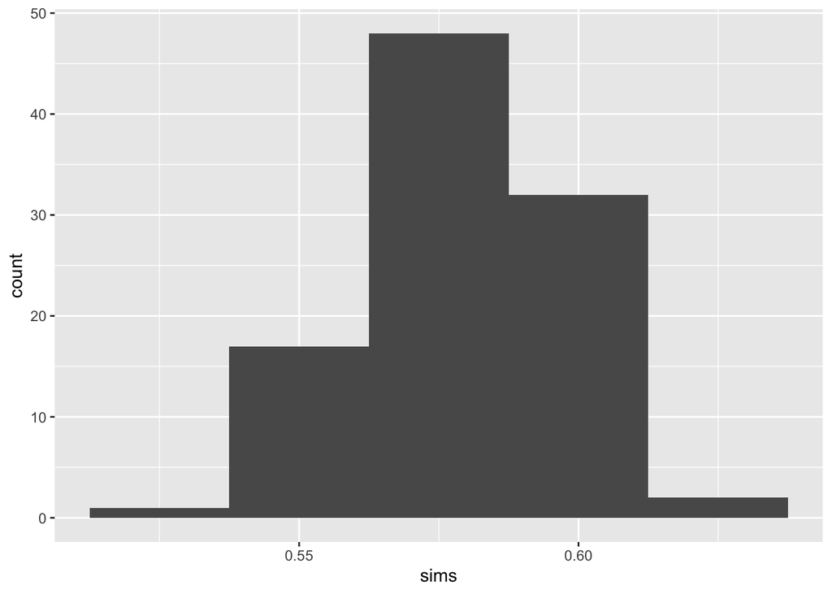

```r
tibble(sims = sim_r_sq) |>
  ggplot(aes(x = sims)) +
  geom_histogram(binwidth = 0.025)
```